# Credit Card Attrition

# 1 Framing

## 1.1 Problem Recognition

After the 2008 crisis, the financial sector and credit card market is more and more witnessing high volatility, acquiring new customers can now cost up to 7 times more than retaining one, which means that losing customers can be a large financial loss [(Glazer, 2019)](https://outline.com/GHqr4t). For this reason it is crucial for banks to be able to predict which customers are likely to end a relationship and stop using the company’s services, in order to retain clients with targeted offers.

## 1.2 Data Collection

Using a data-set provided by a bank on [Kaggle](https://www.kaggle.com/sakshigoyal7/credit-card-customers), the following script will try to solve this business problem. Several provided variables will be analyzed as predictors for a logistic regression, which will infer the probability of losing a customer. The validity of the model will be reported to confirm that suggestions are statistically significant.

| CLIENTNUM | Attrition | Age | Gender | Dependents | EducationLevel | MaritalStatus | IncomeCategory | CardCategory | MonthsOnBook | RelationshipCount | Inactive12Mon | Contacts12Mon | CreditLimit | TotalRevolvingBal | AvgOpenToBuy | TotalTransAmt | TotalTransCt | AvgUtilizationRatio |
| --- | --- | --- | --- | --- | --- | --- | --- | --- | --- | --- | --- | --- | --- | --- | --- | --- | --- | --- |
| 768805383 | Existing Customer | 45 | M | 3 | High School | Married | $60K - $80K | Blue | 39 | 5 | 1 | 3 | 12691 | 777 | 11914 | 1144 | 42 | 0.061 |
| 818770008 | Existing Customer | 49 | F | 5 | Graduate | Single | Less than $40K | Blue | 44 | 6 | 1 | 2 | 8256 | 864 | 7392 | 1291 | 33 | 0.105 |
| 713982108 | Existing Customer | 51 | M | 3 | Graduate | Married | $80K - $120K | Blue | 36 | 4 | 1 | 0 | 3418 | 0 | 3418 | 1887 | 20 | 0.000 |
| 769911858 | Existing Customer | 40 | F | 4 | High School | Unknown | Less than $40K | Blue | 34 | 3 | 4 | 1 | 3313 | 2517 | 796 | 1171 | 20 | 0.760 |
| 709106358 | Existing Customer | 40 | M | 3 | Uneducated | Married | $60K - $80K | Blue | 21 | 5 | 1 | 0 | 4716 | 0 | 4716 | 816 | 28 | 0.000 |
| 713061558 | Existing Customer | 44 | M | 2 | Graduate | Married | $40K - $60K | Blue | 36 | 3 | 1 | 2 | 4010 | 1247 | 2763 | 1088 | 24 | 0.311 |
| 810347208 | Existing Customer | 51 | M | 4 | Unknown | Married | $120K + | Gold | 46 | 6 | 1 | 3 | 34516 | 2264 | 32252 | 1330 | 31 | 0.066 |
| 818906208 | Existing Customer | 32 | M | 0 | High School | Unknown | $60K - $80K | Silver | 27 | 2 | 2 | 2 | 29081 | 1396 | 27685 | 1538 | 36 | 0.048 |
| 710930508 | Existing Customer | 37 | M | 3 | Uneducated | Single | $60K - $80K | Blue | 36 | 5 | 2 | 0 | 22352 | 2517 | 19835 | 1350 | 24 | 0.113 |
| 719661558 | Existing Customer | 48 | M | 2 | Graduate | Single | $80K - $120K | Blue | 36 | 6 | 3 | 3 | 11656 | 1677 | 9979 | 1441 | 32 | 0.144 |

## 1.3 Previous Findings

According to [Copeland (2017)](https://www.wsj.com/articles/if-you-have-29-credit-cards-youre-probably-a-millennial-1490972634), among the first factors enhancing the probability of ending a credit card line is age, millennials in fact tend to open new credit card lines to exploit sign-up bonuses and cancel it before being charged with any significant fee. As a consequence, rewards costs grew an average of 15% in 2018 [(Glazer, 2019)](https://outline.com/GHqr4t), reason why it would be important for banks to purposely use them with targeted clients to foster long-term relationship. Income range is also an important variable, people with higher incomes, a higher credit card limit and a higher level of credit card service are seen to be less likely to interrupt the relationship with a bank [(Adriotis,2019)](https://www.wsj.com/articles/the-credit-card-kingmaker-11553436000). Following the same line of thoughts, looking at loyalty as the time spent as a customer of the bank, the more time the less the probability of stopping to use a service. Accordingly, it is expected that people that would be more likely to drop a credit card would have lower spending, but still a significant amount of transactions [(Glazer, 2019)](https://outline.com/GHqr4t). Finally the number of products held by a customer can help identify behavior, an ideal client usually has more products with the bank [(Shevlin, 2019)](https://www.forbes.com/sites/ronshevlin/2019/05/01/why-are-fewer-consumers-switching-banks-because-checking-accounts-have-become-paycheck-motels/?sh=6fc2546a2aa9).

## 1.4 Hypotheses

The following hypotheses will be tested throughout the model, the probability of churning for a customers is claimed to be a function of the variables taken into consideration, meaning that the null-hypothesis for this model is:

$$\begin{aligned}
H_0 : \beta_i = 0
\end{aligned}$$
The coefficients found for the variables would be equal to zero, meaning that it would not influence the probability of attrition. On the contrary the alternative hypothesis to test, is that the coefficients will be different from zero, and the chance of attrition is actually found to be a function of the following variables:
$$\begin{aligned}
H_A : \beta_i \neq 0
\end{aligned}$$

$$\begin{aligned}
H_A: P(attrition) = \beta_0 + \beta_1(\text{Age}) + \beta_2(\text{IncomeCategory}) + \beta_3(\text{MonthsOnBook}) + \beta_4(\text{RelationshipCount}) \\+ \beta_5(\text{Contacts12Mon}) + \beta_6(\text{CreditLimit}) + \beta_7(\text{TotalRevolvingBalance}) + \\ \beta_8(\text{AvgUtilizationRatio}) + \beta_9(\text{TotalTransAmt}) + \beta_x(\text{TotalTransCt}) +\epsilon \\
\end{aligned}$$

# 2 Solving

## 2.1 Variables

Firstly, it is important to have a clear understanding of the variables selected from the data source:

**Demographics:**  
*Age* | Age of customer  
*Gender* | Gender of customer  
*EducationLevel* | Education level of customer  
*MaritalStatus* | Marital status of customer  
*IncomeCategory* | Range of customer income

**Bank Involvement:**  
*Attrition* | If a customer is still using the service or left the bank  
*CardCategory* | Level of card owned by customer  
*MonthsOnBook* | Number of months a customer has been customer of the bank  
*RelationshipCount* | Number of products held by a customer  
*ContactsCount12Mon* | Number of contacts with the bank in the last 12 months  
*Inactive12Mon* | Number of months inactive over the last 12 months  
*CreditLimit* | Credit card limit of a customer  
*TotalRevolvingBal* | Cumulative revolving balance of a customer  
*TotalTransCt* | Number of transactions executed in the last 12 months  
*TotalTransAmt* | Amount spent in the last 12 months  
*AvgUtilizationRatio* | Average ratio of card utilization

Since the attrition is what the model focuses on, the ratio of customers that stopped using the bank services for this particular data-set would give a first overview of the problem:

| Attrition | n |
| --- | --- |
| Attrited Customer | 1627 |
| Existing Customer | 8500 |

## 2.2 Data Analysis

### 2.2.1 Demographics

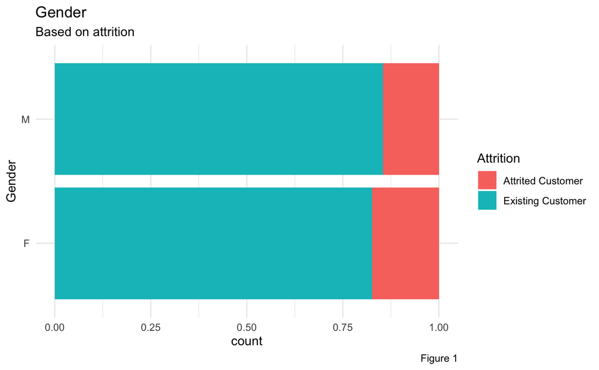

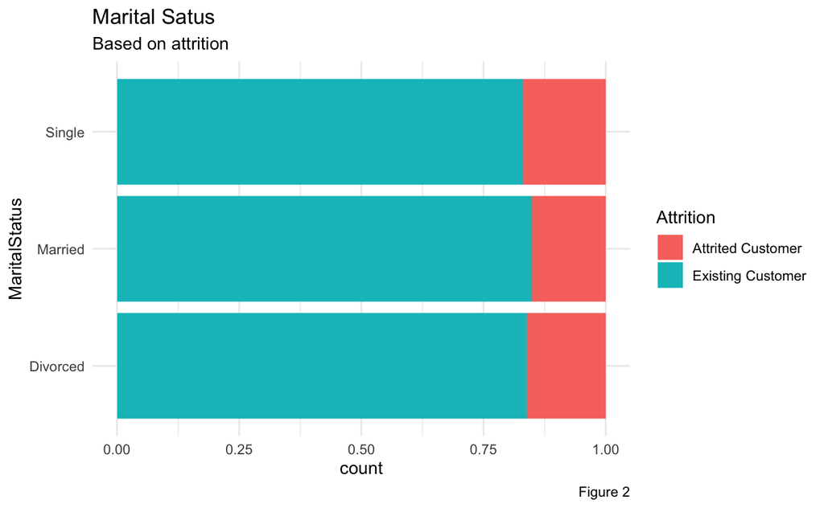

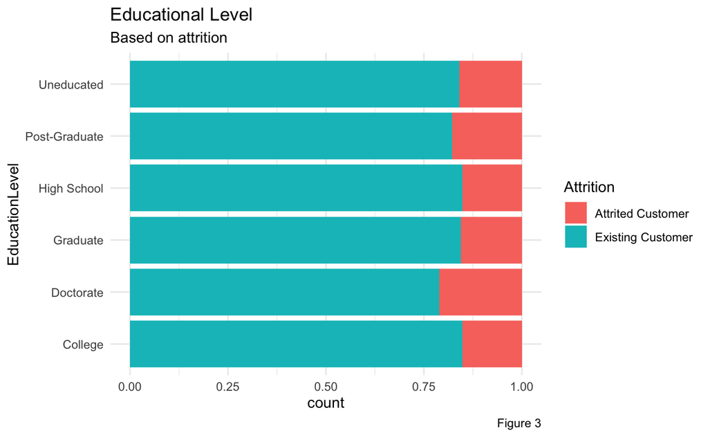

Throughout the observations, a good balance between males (47%) and females (53%) is found, highlighting that the analysis is fair in terms of proportions. *Figure 1* also shows that the attrition ratio among the sexes is very similar, indicating that gender is most likely not a factor that highly influences the probability of attrition. The same can be noticed for marital status of clients in *Figure 2*. Furthermore, also the educational level does not show substantial differences when comparing the different levels in *Figure 3*. No relevant unbalance has been found in marital status and education level proportions.  
________________________________________________________________________________

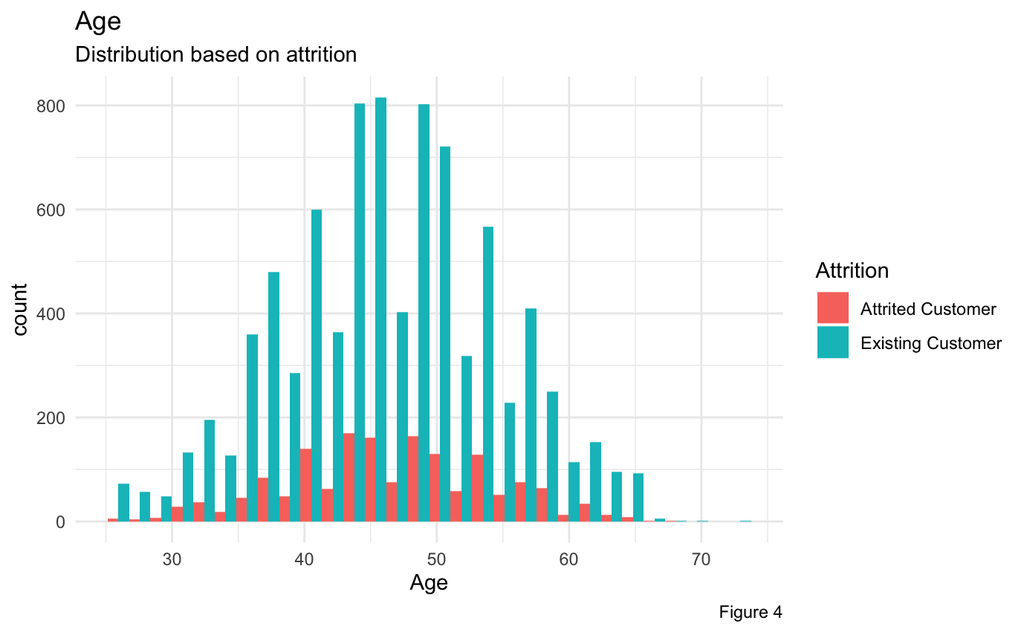

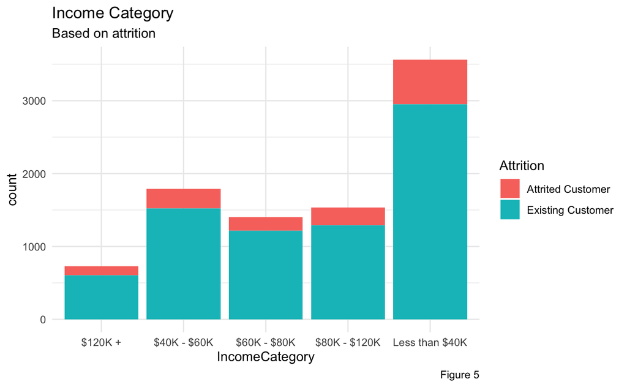

In *Figure 5* it is highlighted the fact that, as expected, the majority of attrited customers are from lower income categories, meaning that a lower income will result in a higher probability of leaving the bank. However, it is also possible to observe from the chart that the ratios seem proportionate with the total number of customers present in each income category, lowering the overall impact that the variable will have on the predicted value.  
________________________________________________________________________________

### 2.2.2 Bank Involvement

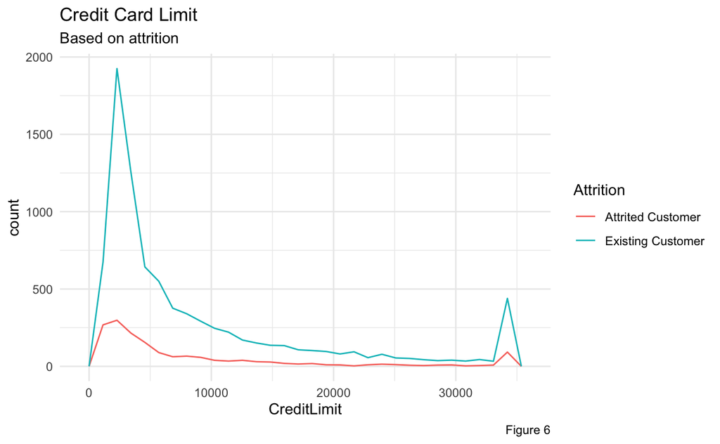

*Figure 6* shows the credit limit of existing and lost customers. Again, one of the initial hypothesis does not seem to apply as strongly as expected, since both type of clients present a similar distribution of credit card maximum allowance. Existing customers do tend to have a slightly higher credit card limit (considering they are often those with an higher income, as seen in *Figure 5*). Moreover, this chart makes it possible to locate outliers for this particular variable, a few clients have in fact a very high allowance compared to the rest of the observations. Do these outliers use more products compared to others?  
________________________________________________________________________________

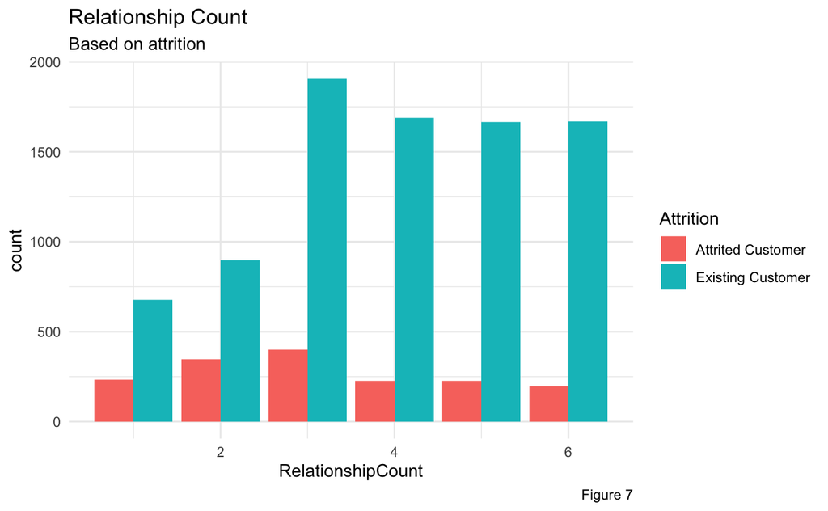

Taking into consideration the number of products held by a client, *Figure 7* highlights that it is in fact true that customers with more products have a lower ratio of attrition. Leaving customers are appearing to grow up to 3 products and lower substantially as one more is added. The entire spectrum of products goes from 1 to 6, no client, even the previous outliers found in credit limit have more. Knowing how many products are used, it is interesting to look at how and how much these are used.  
________________________________________________________________________________

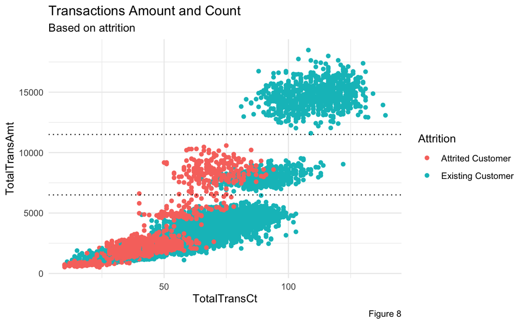

The scatterplot in *Figure 8* takes into consideration both the number of transactions made by a customer and the relative amount spent in a period of 12 months. Filtering by attrition we can see that a pattern shows up, those that spend very high amounts of money (above the higher dotted line) can be considered the loyal customers. Those leaving the bank seem to have less transactions for similar values of money spent. However, it is not unlikely that leaving customers are already adopting services from other banks, explaining the lower count of transactions, so lets look at the utilization ratio.  
________________________________________________________________________________

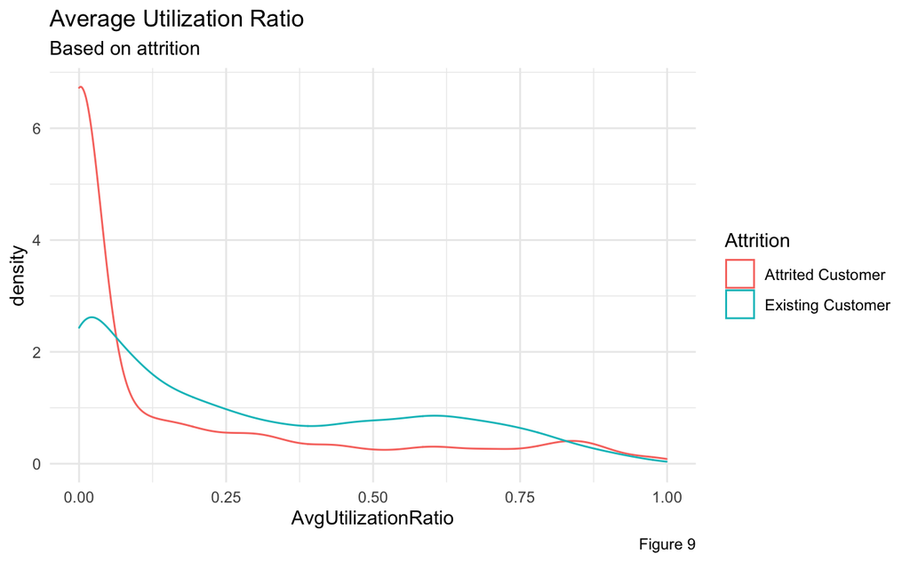

As expected, the distribution in *Figure 9* displays the fact that the majority of customers that left have a much lower utilization ratios, and show some outliers with higher ratios, whereas existing customers follow a more flat density curve. Since customers that are likely to leave use less the bank services, the next thing to understand would be if they also come into contact with the bank on a different basis.  
________________________________________________________________________________

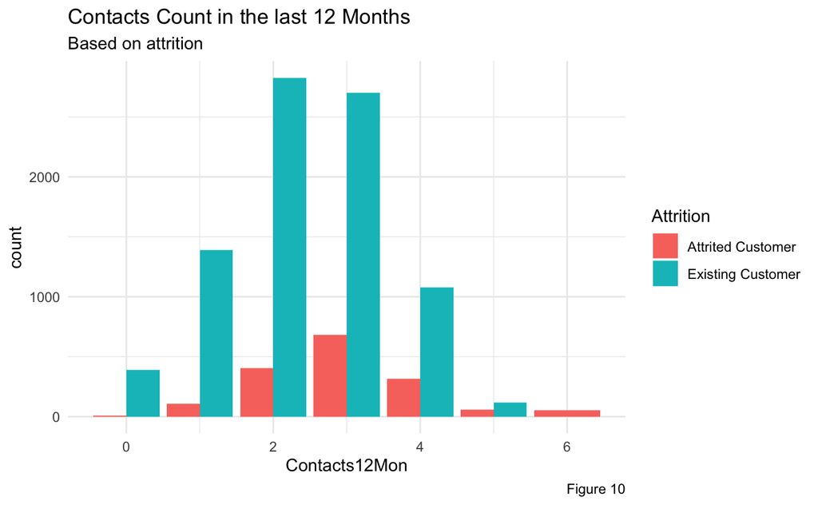

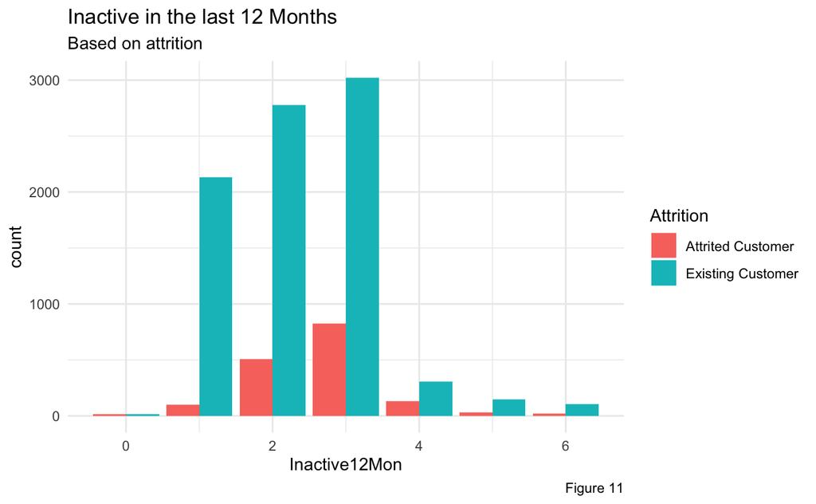

**Outliers**  
Finally, outliers that might have been missed previously are considered using boxplots for months spent as a customer of the company, the revolving balance of a client and the transactions amount and count.

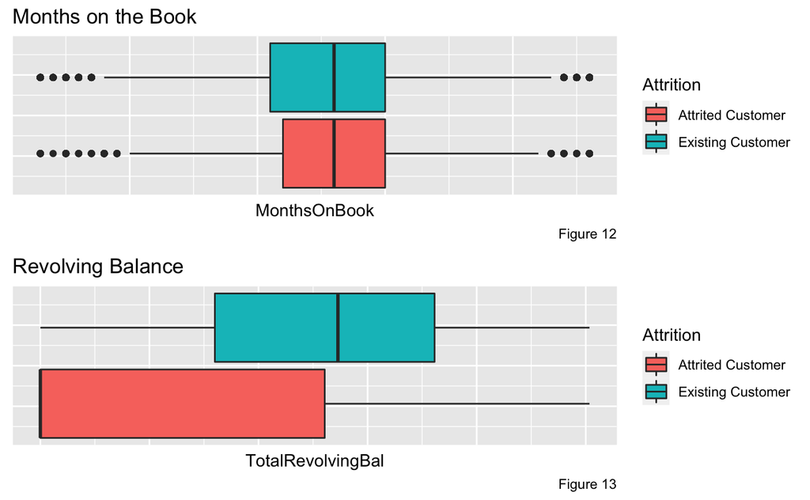

For what concerns months on the book, the distributions seem very similar for existing and lost customers, with very similar medians and outliers, so it is possible to check similarities over averages as well:

| Attrition | Average MonthsOnBook |
| --- | --- |
| Attrited Customer | 36.18 |
| Existing Customer | 35.88 |

They are almost identical, showing that attrition is likely not to depend on the time already spent with the bank, surprisingly the average leaving customer has been client of the bank for longer. Moreover, the high majority of lost customers tend to have much lower revolving balances.  
________________________________________________________________________________

After analyzing the various factor, the alternative hypothesis for the logistic model that will be developed changes as following:
$$\begin{aligned}
H_A : \beta_i \neq 0
\end{aligned}$$

$$\begin{aligned}
H_A: P(attrition) = \beta_0 + \beta_1(\text{RelationshipCount}) + \beta_2(\text{Contacts12Mon}) + \beta_3(\text{Inactive12Mon}) +\\ \beta_4(\text{TotalRevolvingBalance}) + \beta_5(\text{TotalTransCt}) + \beta_6(\text{TotalTransAmt}) +\epsilon \\
\end{aligned}$$
*“The average Utilization ratio was also removed as statistical significance was not proved in further analysis (see next table explanation).”*

# 3 Modelling

## 3.1 Logistic Regression

A logistic regression of the attrition probability as a function of the variables stated above is able to output a value from 0 to 1 as chance of an observed client to leave the bank. Firstly, lets look at the model reliability, which was ran both on the entire data-set and on a train-sample:

| term | estimate | std.error | statistic | p.value |
| --- | --- | --- | --- | --- |
| (Intercept) | 3.0542427748 | 2.025140e-01 | 15.08164 | 2.138996e-51 |
| RelationshipCount | -0.4701195005 | 2.579154e-02 | -18.22766 | 3.113451e-74 |
| Inactive12Mon | 0.4788877778 | 3.537523e-02 | 13.53738 | 9.409138e-42 |
| Contacts12Mon | 0.5050233222 | 3.368373e-02 | 14.99309 | 8.146871e-51 |
| TotalRevolvingBal | -0.0010227513 | 4.367242e-05 | -23.41870 | 2.756345e-121 |
| TotalTransAmt | 0.0004037675 | 2.099387e-05 | 19.23264 | 1.973273e-82 |
| TotalTransCt | -0.1084127378 | 3.303799e-03 | -32.81456 | 3.649820e-236 |

*As the coefficients are indeed different from zero, it is possible to reject the null-hypothesis.*

The first values to observe are the p-value and t-statistic for every coefficient to understand if the selected variables are relevant, the p-values are all way lower than a standard alpha taken at **0.05**, apart from the Average Utilization Ratio, which appeared to be much higher. Being also the only variable with a t-statistic lower than the absolute value of 2 and a very high standard error (high variability), AvgUtilizationRatio was the only predictor not statistically significant, and was therefore removed from the model.

When it comes to the validity of the model itself many factors can give valuable insights. A logistic regression with [Frank Harrell’s](https://hbiostat.org/doc/rms.pdf) method was also used to gain some of these indicators. Disctimination indexes have been found as follow:  
**Dxy** = *0.8*, this represents the correlation between predicted and observed values and is considered to be of relevant when higher than 0.6, indicating a good similarity between prediction and observation.  
**C-index** = *0.9*, representing the quality of prediction (0.5 would be a random prediction), pointing again at a very good classificatory quality.  
However, considering the amount of predictors used and the possible presence of confounding factors these numbers are also likely to be indicators of an overoptimistic model. Plotting the distribution of the predicted leaving customer by observed leaving customers it is possible to see how many would be correctly guessed with this model:

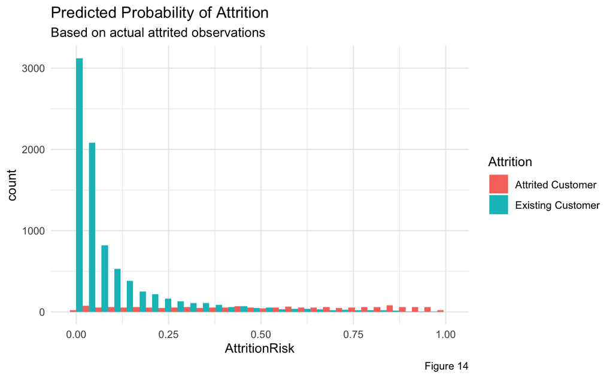

It seems that the majority of customers staying with the bank where correctly predicted, however, lost customers show a widely spread distribution over the risk of attrition, indicating a far less precise prediction. This might also be caused by the low rate of “attrited” observations in the data-set.  
To be more specific about the reliability of the model, the accuracy and a confusion matrix can be computed using a set threshold, lets consider all predicted values above *0.5* as likely to leave the bank.  
The accuracy of the model results to be:

| value |
| --- |
| 0.89 |

An accuracy of *89%* is significantly high, this might again come from the fact that the majority of observations are not lost customers (the ones that are mostly predicted correctly). By forecasting on default that people will not be leaving (predicting against the rare outcome), the model is able to obtain “easy” correct hits. For this reason, when evaluating such model it is crucial to look at the accuracy separately for each category, a confusion matrix allows to observe exactly that:

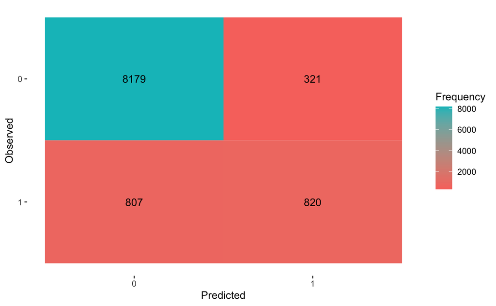

*Predicted and observed existing customers are indicated with value = 0, predicted and observed leaving customers are indicated with value = 1.*

When considering only leaving customers, the accuracy does in fact go down to *50%*. The substantial problem with this result is that, as stated initially, it is very expensive for a bank to lose customers and try to acquire new ones as compared to retain existing ones. Meaning that, the probability of a Type 1 error (trying to retain a client when not necessary) is far less financially risky than a Type 2 error (not trying to retain a customer when it is needed). Following this model the probabilities of committing a Type 2 error are consistently higher than those of committing a Type 1 error.

## 3.2 Testing

Lets now test the outcomes of the model with a smaller random sample of about 70% of the data-set (a seed is set in order to always refer to the same output when comparing).

| term | estimate | std.error | statistic | p.value |
| --- | --- | --- | --- | --- |
| (Intercept) | 3.1591519110 | 2.449295e-01 | 12.89821 | 4.606697e-38 |
| RelationshipCount | -0.4866537350 | 3.110519e-02 | -15.64542 | 3.570237e-55 |
| Inactive12Mon | 0.4855628834 | 4.330497e-02 | 11.21264 | 3.535044e-29 |
| Contacts12Mon | 0.4987638900 | 4.024473e-02 | 12.39327 | 2.842091e-35 |
| TotalRevolvingBal | -0.0010357179 | 5.212055e-05 | -19.87159 | 7.170115e-88 |
| TotalTransAmt | 0.0004092996 | 2.501974e-05 | 16.35907 | 3.748172e-60 |
| TotalTransCt | -0.1093491487 | 3.959473e-03 | -27.61710 | 6.935996e-168 |

The values with a higher standard error are of course the ones to record a more distinctive change, however, the coefficients are all maintaining very similar values to the model ran with the whole data-set. In terms of accuracy:

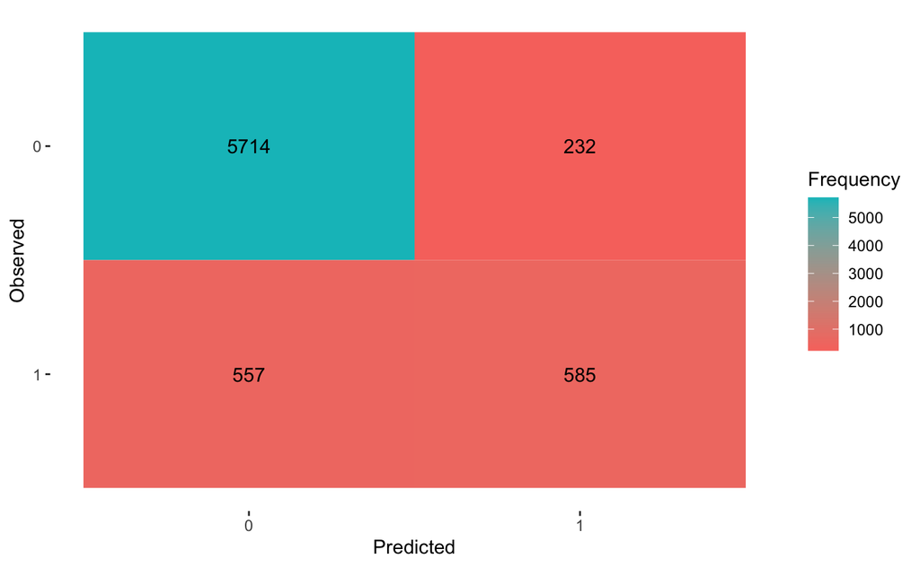

The overall accuracy remains the same at *89%*, the accuracy for the prediction of leaving customers is now *51%*, slightly higher than before. Thus, the testing shows a good approach to the data-set, generally indicating a lower risk of over-fitting when replicating the model.

## 3.3 Results

To conclude, assumptions can now be made taking into account the validity of the model.

- The coefficients indicate that the number of contacts made with the bank in the last 12 months is the most relevant predictor over attrition rate, the bank should check for customers that are making a higher than usual contacts with the branch and focus on service and offers to be proposed.
- The second most important predictor is the inactivity of a client, those that have been inactive for a longer than average time should be involved and target with retaining strategies. This might appear as a paradox, a customer that contacts the bank many times is not likely to be inactive for a long time, however, this makes sense as it is simply identifying two different types of possible leaving customers.
- The next predictor to consider is the number of products held, trying to augment the extent of the relationship with a customer can function as a way to strengthen the relationship and enhance commitment. Clients that have less products are more likely to be the ones that have to be targeted, however, more products tend to lower the credit score of a consumer, meaning that based on the income category, it might be better to focus on the quality of the existing service.
- Customers that are making a lower than usual number of transactions are also important to target with retaining strategies.
- Considering Revolving balance and the amount spent for each transaction, the coefficients indicate that the influence of these variables on the attrition probability is very low, but when needed to be assessed, customers to target are those with a low revolving balance and higher transactions amount. The reason why this combination is not highly explanatory of the attrition risk distribution is possibly because it is very common for clients to be found in these circumstances.

## 3.4 Limitations

The low rate of leaving customers have been found to be a big obstacle in determining the model accuracy. Furthermore, the reasons why a client decides to leave a bank is very likely to be influenced on variables not listed in this data source, also considering the difficulty of recording Country regulations, quality of service, past experiences in branches, banking prices and comparison with the competition. The perception of those might not be the same for all type of customers included in the study.

# 4 References

Andriotis, A. (2019). The Credit-Card Kingmaker. WSJ. Retrieved 7 December 2020, from https://www.wsj.com/articles/the-credit-card-kingmaker-11553436000

Copeland, R. (2017). If You Have 29 Credit Cards, You’re Probably a Millennial. WSJ. Retrieved 7 December 2020, from https://www.wsj.com/articles/if-you-have-29-credit-cards-youre-probably-a-millennial-1490972634

Glazer, E. (2019). Rewards Credit Cards Gained a Fanatic Following—Now Banks Are Pulling Back. Forbes. Retrieved 7 December 2020, from https://outline.com/GHqr4t

Harrell, F. (2020). Regression Modeling Strategies. Retrieved 18 December 2020, from https://hbiostat.org/doc/rms.pdf

Shevlin, R. (2019). Why People Don’t Switch Banks Anymore. Forbes. Retrieved 14 December 2020, from https://www.forbes.com/sites/ronshevlin/2019/05/01/why-are-fewer-consumers-switching-banks-because-checking-accounts-have-become-paycheck-motels/?sh=6fc2546a2aa9